# CPAM2024_Precipitacao_Cubatao

## Trabalho CPAM 2024

#### Título: A Influência da Precipitação na Elevação do Nível do Rio Cubatão do Sul em SC

#### Data: Agosto/2024

#### Equipe:

- Alexandre Nuernberg - alexandreberg@gmail.com
- Eduardo Conceição
- Gilmar Florêncio
- Juliana Portella Bernardes
- Nicolas Firmino Flores

# Definição das bibliotecas

```python
import os                           # faz a movimentação de arquivos, pastas e variáveis de ambiente
import pandas as pd                 # trabalhar com planilhas e DataFrames e ferramentas para manipulação e análise de dados
import matplotlib.pyplot as plt     # biblioteca para visualização de dados semelhante ao MATLAB, para criar gráficos e visualizações de alta qualidade, como gráficos de linha, histogramas, dispersões
import numpy as np                  # para computação científica, fornece suporte para arrays multidimensionais e funções matemáticas
import seaborn as sns               # para criar gráficos estatísticos atraentes e informativos, como gráficos de dispersão com várias variáveis e mapas de calor
from scipy.stats import norm        # estatística distribuição normal (gaussiana) como cálculos de probabilidade, geração de números aleatórios e ajuste de dados a uma distribuição normal
import netCDF4 as nc                # abrir arquivos gerados pelo Merge no formato netCDF4
import geopandas as gpd             # trabalhar com mapas de coordenadas geográficas
import itertools                    # combinaçãoes matemáticas
```

#### Análise das cotas da estação: ETA CASAN MONTANTE

#### Análise das cotas da estação: ETA CASAN MONTANTE

##### Arquivo: Cotas_Estacao_100.csv

##### Cota de Alerta: 214 cm

##### Código: 84150100

```python
# Caminho do arquivo (use r'' para evitar problemas com caracteres especiais)
caminho_arquivo = r'../input_data/Cotas_Estacao_100.csv'

# Leitura do CSV com separador ';'
df = pd.read_csv(caminho_arquivo, sep=';')

# Create a list to store the data in the desired format
data = []

# Iterate over the rows of the DataFrame
for index, row in df.iterrows():
    data_hora = pd.to_datetime(row['Data'] + ' ' + row['hora'])
    for dia, cota in row.items():
        # Skip the 'Data' and 'hora' columns
        if dia in ['Data', 'hora']:
            continue
        # Convert the 'dia' to integer
        dia = int(dia)
        # Check if 'dia' is within valid range (1-31)
        if 1 <= dia <= 31:
            # Create a new datetime index and add data to the list
            data.append({'Data': data_hora + pd.to_timedelta(dia - 1, unit='d'), 'Cotas': cota, 'Data_hora': data_hora})

# Create a new DataFrame from the list of data
df_unpivot = pd.DataFrame(data)

# Get unique values from 'Data_hora' column
unique_data_hora = df_unpivot['Data_hora'].unique()

# If there are non-numeric values in the 'Data_hora' column, convert them to numeric, ignoring errors
if not all(isinstance(x, (int, float)) for x in unique_data_hora):
    df_unpivot['Data_hora'] = pd.to_numeric(df_unpivot['Data_hora'], errors='coerce')

# Convert the 'Data_hora' column to datetime64[ns]
df_unpivot['Data_hora'] = pd.to_datetime(df_unpivot['Data_hora'], unit='ns')

# Convertendo a coluna 'Data' para o tipo datetime
df_unpivot['Data'] = pd.to_datetime(df_unpivot['Data'])

# Criando as colunas separadas para data e hora
df_unpivot['data'] = df_unpivot['Data'].dt.date
df_unpivot['hora'] = df_unpivot['Data'].dt.time

# Renomeando a coluna "Cotas" para "cotas"
df_unpivot = df_unpivot.rename(columns={'Cotas': 'cotas'})

# Reset the index to make 'Data' a regular column
df_unpivot = df_unpivot.reset_index()

# Drop the 'Data' and 'Data_hora' columns
df_unpivot_filtered = df_unpivot.drop(columns=['Data', 'Data_hora'])

# Display the first 10 rows of the resulting DataFrame
print("Cabeçalho do arquivo Cotas_Estacao_100.csv:\n")
print(df_unpivot_filtered.head(10).to_markdown(index=False, numalign="left", stralign="left"))

# Debug:
# Exibindo o DataFrame após a renomeação
display(df_unpivot_filtered)

# Exibindo informações iniciais
# print("\nHeader do arquivo Cotas_Estacao_100.csv:\n")
# df_unpivot_filtered.head(62)  # Use print() para exibir o resultado do head()
```

```
Cabeçalho do arquivo Cotas_Estacao_100.csv:

| index   | cotas   | data       | hora     |
|:--------|:--------|:-----------|:---------|
| 0       | 190     | 1989-01-01 | 07:00:00 |
| 1       | 154     | 1989-01-02 | 07:00:00 |
| 2       | 151     | 1989-01-03 | 07:00:00 |
| 3       | 268     | 1989-01-04 | 07:00:00 |
| 4       | -100    | 1989-01-05 | 07:00:00 |
| 5       | 170     | 1989-01-06 | 07:00:00 |
| 6       | 266     | 1989-01-07 | 07:00:00 |
| 7       | 310     | 1989-01-08 | 07:00:00 |
| 8       | 334     | 1989-01-09 | 07:00:00 |
| 9       | 210     | 1989-01-10 | 07:00:00 |
```

|  | index | cotas | data | hora |
| --- | --- | --- | --- | --- |
| 0 | 0 | 190 | 1989-01-01 | 07:00:00 |
| 1 | 1 | 154 | 1989-01-02 | 07:00:00 |
| 2 | 2 | 151 | 1989-01-03 | 07:00:00 |
| 3 | 3 | 268 | 1989-01-04 | 07:00:00 |
| 4 | 4 | -100 | 1989-01-05 | 07:00:00 |
| ... | ... | ... | ... | ... |
| 25043 | 25043 | 117 | 2023-06-27 | 17:00:00 |
| 25044 | 25044 | 116 | 2023-06-28 | 17:00:00 |
| 25045 | 25045 | 115 | 2023-06-29 | 17:00:00 |
| 25046 | 25046 | 115 | 2023-06-30 | 17:00:00 |
| 25047 | 25047 | -100 | 2023-07-01 | 17:00:00 |

25048 rows × 4 columns

### Agrupando o DataFrame pela coluna 'data' e calculando o máximo da coluna 'cotas' para cada dia

##### Isso é feito porque existem dois valores de cotas diárias um das 7:00 e outro das 17:00

##### Apenas o valor de cota mais alta do dia será usado na análise e o outro será excluido

#### DF: *df_cs_max_cota_dia*

```python
df_cs_max_cota_dia = df_unpivot_filtered.groupby('data')['cotas'].max().reset_index()

# Exibindo o cabeçalho do dataframe
print("\nDF df_cs_max_cota_dia (Máxima cota do dia da Estação CS - CASAN MONTANTE):")
print(df_cs_max_cota_dia.head(10).to_markdown(index=False, numalign="left", stralign="left"))

# Debug:
# print("\nChecagem do tipo de dados (DType) das colunas:")
df_cs_max_cota_dia.info()
```

```
DF df_cs_max_cota_dia (Máxima cota do dia da Estação CS - CASAN MONTANTE):
| data       | cotas   |
|:-----------|:--------|
| 1989-01-01 | 190     |
| 1989-01-02 | 154     |
| 1989-01-03 | 162     |
| 1989-01-04 | 268     |
| 1989-01-05 | 626     |
| 1989-01-06 | 334     |
| 1989-01-07 | 266     |
| 1989-01-08 | 320     |
| 1989-01-09 | 334     |
| 1989-01-10 | 210     |
<class 'pandas.core.frame.DataFrame'>
RangeIndex: 12295 entries, 0 to 12294
Data columns (total 2 columns):
 #   Column  Non-Null Count  Dtype
---  ------  --------------  -----
 0   data    12295 non-null  object
 1   cotas   12295 non-null  int64
dtypes: int64(1), object(1)
memory usage: 192.2+ KB
```

#### A estação ETA CASAN MONTANTE possui uma cota de alerta de inundação de 214cm

##### Filtrando os dados com cota igual ou acima do nivel de alerta 214 cm

##### Aqui serão filtrados exclusivamente os valores de cotas dentro desse range, os demais serão descartados.

DF: *df_cs_max_cota_alerta*

```python
# Classificando por data em ordem crescente (opcional, mas recomendado)
df_cs_max_cota_dia['data'] = df_cs_max_cota_dia['data'].sort_values()

# Filtrando as cotas maiores ou iguais a 214 cm no período
df_cs_max_cota_alerta = df_cs_max_cota_dia[df_cs_max_cota_dia['cotas'] >= 214]

# Salvando o DataFrame filtrado no período
df_cs_max_cota_alerta.to_csv('../output_data/database/df_cs_max_cota_alerta.csv')  # Nome do arquivo ajustado

#Debug:
# Exibindo informações sobre o DataFrame filtrado
print("\nInfo DF df_cs_max_cota_alerta:")
df_cs_max_cota_alerta.info()

# Exibindo o DataFrame resultante
print("\nDF df_cs_max_cota_alerta:")
print("Cotas acima da cota de alerta (214cm) da Estação CS - CASAN MONTANTE):")
# display(df_cs_max_cota_alerta)
print(df_cs_max_cota_alerta.head(10).to_markdown(index=False, numalign="left", stralign="left"))
```

```
Info DF df_cs_max_cota_alerta:
<class 'pandas.core.frame.DataFrame'>
Index: 559 entries, 3 to 12194
Data columns (total 2 columns):
 #   Column  Non-Null Count  Dtype
---  ------  --------------  -----
 0   data    559 non-null    object
 1   cotas   559 non-null    int64
dtypes: int64(1), object(1)
memory usage: 13.1+ KB

DF df_cs_max_cota_alerta:
Cotas acima da cota de alerta (214cm) da Estação CS - CASAN MONTANTE):
| data       | cotas   |
|:-----------|:--------|
| 1989-01-04 | 268     |
| 1989-01-05 | 626     |
| 1989-01-06 | 334     |
| 1989-01-07 | 266     |
| 1989-01-08 | 320     |
| 1989-01-09 | 334     |
| 1989-01-30 | 328     |
| 1989-02-01 | 244     |
| 1989-02-02 | 247     |
| 1989-02-03 | 260     |
```

#### Pegando apenas os valores do período de 2000 à 2022 para análise

##### Convertendo a coluna data de texto para o formato de data

##### Nivelando os dados para a período comum entre os dados de nível, chuva e maré (2000-01-01 até 2022-12-31)

##### DF: *df_cs_max_cota_dia_periodo*

```python
# Erro de lógica
# Pegando apenas os valores do período de 2000 à 2022 para análise
# Convertendo a coluna data de texto para o formato de data
# Nivelando os dados para a período comum entre os dados de nível, chuva e maré (2000-01-01 até 2022-12-31)
# Nesse período existem 8.401 dias, só que 275 dias estão faltando (sem dados).

# Convertendo a coluna 'data' para o tipo datetime
df_cs_max_cota_alerta['data'] = pd.to_datetime(df_cs_max_cota_alerta['data'])

# Filtrando o DataFrame pela coluna 'data' no intervalo desejado
df_cs_max_cota_dia_periodo = df_cs_max_cota_alerta[(df_cs_max_cota_alerta['data'] >= '2000-01-01') & (df_cs_max_cota_alerta['data'] <= '2022-12-31')]

#Debug:
# análises estatísticas dos dados entre 2000 e 2022:
display(df_cs_max_cota_dia_periodo.describe())

# contagem dos registros nesse periodo:
# df_cs_max_cota_dia_periodo.info()

# Exibindo o DataFrame resultante
print("\nDF df_cs_max_cota_dia_periodo:")
print(df_cs_max_cota_dia_periodo)
print(df_cs_max_cota_dia_periodo.head(10).to_markdown(index=False, numalign="left", stralign="left"))
# df_cs_max_cota_dia_periodo.info()
```

|  | data | cotas |
| --- | --- | --- |
| count | 287 | 287.000000 |
| mean | 2011-11-08 23:39:55.818815232 | 308.034843 |
| min | 2000-01-11 00:00:00 | 214.000000 |
| 25% | 2007-06-20 12:00:00 | 231.000000 |
| 50% | 2010-11-29 00:00:00 | 268.000000 |
| 75% | 2017-05-20 12:00:00 | 328.000000 |
| max | 2022-12-28 00:00:00 | 1115.000000 |
| std | NaN | 125.768986 |

```
DF df_cs_max_cota_dia_periodo:
            data  cotas
3997  2000-01-11    266
3998  2000-01-12    305
4000  2000-01-14    287
4001  2000-01-15    256
4002  2000-01-16    276
...          ...    ...
12100 2022-12-19    274
12101 2022-12-20    431
12102 2022-12-21    244
12107 2022-12-26    225
12109 2022-12-28    250

[287 rows x 2 columns]
| data                | cotas   |
|:--------------------|:--------|
| 2000-01-11 00:00:00 | 266     |
| 2000-01-12 00:00:00 | 305     |
| 2000-01-14 00:00:00 | 287     |
| 2000-01-15 00:00:00 | 256     |
| 2000-01-16 00:00:00 | 276     |
| 2000-01-17 00:00:00 | 298     |
| 2000-02-14 00:00:00 | 310     |
| 2000-02-15 00:00:00 | 325     |
| 2000-02-16 00:00:00 | 278     |
| 2000-03-06 00:00:00 | 510     |
```

### Substituir o nome da colunas "cotas" que é semelhante nos dados das duas estações de fluviométrics por "cotas_cs".

### Para identificar que é da estação CASAN MONTANTE (CS)

```python
df_cs_max_cota_dia_periodo = df_cs_max_cota_dia_periodo.rename(columns={'cotas': 'cotas_cs'})

# Exibindo o cabeçalho do dataframe
print("\nDF df_cs_max_cota_dia_periodo (Máxima cota do dia da Estação CS - CASAN MONTANTE):")
print(df_cs_max_cota_dia_periodo.head(10).to_markdown(index=False, numalign="left", stralign="left"))

# Salva do DataFrame Eta casan cota máxima do dia de todo banco dados.
df_cs_max_cota_dia_periodo.to_csv('../output_data/database/df_cs_max_cota_dia_periodo.csv')
```

```
DF df_cs_max_cota_dia_periodo (Máxima cota do dia da Estação CS - CASAN MONTANTE):
| data                | cotas_cs   |
|:--------------------|:-----------|
| 2000-01-11 00:00:00 | 266        |
| 2000-01-12 00:00:00 | 305        |
| 2000-01-14 00:00:00 | 287        |
| 2000-01-15 00:00:00 | 256        |
| 2000-01-16 00:00:00 | 276        |
| 2000-01-17 00:00:00 | 298        |
| 2000-02-14 00:00:00 | 310        |
| 2000-02-15 00:00:00 | 325        |
| 2000-02-16 00:00:00 | 278        |
| 2000-03-06 00:00:00 | 510        |
```

#### Plotagem dos gráficos de Histograma e Boxplot para a estação ETA CASAN Montante

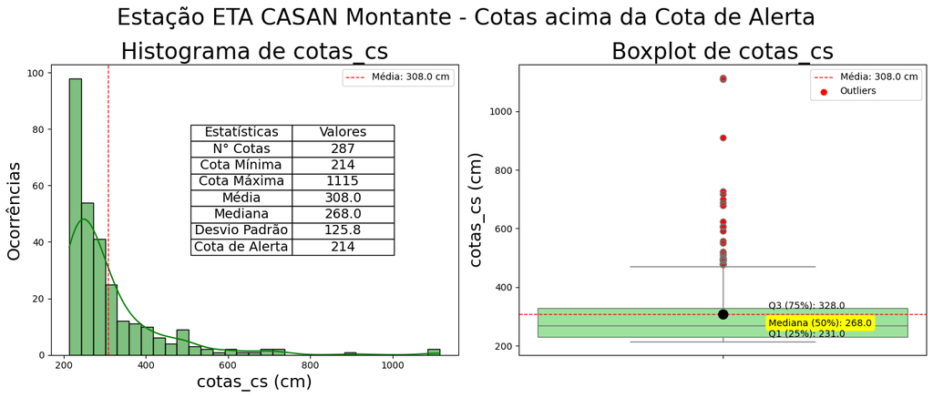

|  | data | cotas_cs |
| --- | --- | --- |
| count | 287 | 287.000000 |
| mean | 2011-11-08 23:39:55.818815232 | 308.034843 |
| min | 2000-01-11 00:00:00 | 214.000000 |
| 25% | 2007-06-20 12:00:00 | 231.000000 |
| 50% | 2010-11-29 00:00:00 | 268.000000 |
| 75% | 2017-05-20 12:00:00 | 328.000000 |
| max | 2022-12-28 00:00:00 | 1115.000000 |
| std | NaN | 125.768986 |

```python
# Criação dos subplots
fig, axes = plt.subplots(1, 2, figsize=(14, 6))  # 1 linha, 2 colunas

# Histograma
sns.histplot(df_cs_max_cota_dia_periodo['cotas_cs'], ax=axes[0], kde=True, color='green')
axes[0].set_xlabel('cotas_cs (cm)', fontsize=18)
axes[0].set_ylabel('Ocorrências', fontsize=18)
axes[0].set_title('Histograma de cotas_cs', fontsize=24)

# Criação da Tabela:
# Calcula as estatísticas para a tabela
count = df_cs_max_cota_dia_periodo['cotas_cs'].count()
min_cota = df_cs_max_cota_dia_periodo['cotas_cs'].min()
max_cota = df_cs_max_cota_dia_periodo['cotas_cs'].max()
media = df_cs_max_cota_dia_periodo['cotas_cs'].mean()
mediana = df_cs_max_cota_dia_periodo['cotas_cs'].median()
desvio_padrao = df_cs_max_cota_dia_periodo['cotas_cs'].std()  # Calcula o desvio padrão
nivel_alerta = 214

# Dados da tabela
dados_tabela = {
    'Estatísticas': ['N° Cotas', 'Cota Mínima', 'Cota Máxima', 'Média', 'Mediana', 'Desvio Padrão', 'Cota de Alerta'],
    'Valores': [count, min_cota, max_cota, f'{media:.1f}', f'{mediana:.1f}', f'{desvio_padrao:.1f}', nivel_alerta]
}

# Cria um DataFrame para a tabela
df_tabela = pd.DataFrame(dados_tabela)

# Cria a tabela no subplot do histograma
# tabela = axes[0].table(cellText=df_tabela.values, colLabels=df_tabela.columns, loc='upper right', cellLoc='center', bbox=[0.455, 0.3425, 0.5, 0.45])
tabela = axes[0].table(cellText=df_tabela.values, colLabels=df_tabela.columns, loc='upper right', cellLoc='center', bbox=[0.3425, 0.3425, 0.5, 0.45])

# Formata a tabela (opcional)
tabela.auto_set_font_size(False)
tabela.set_fontsize(14)
tabela.scale(1, 1.5)  # Ajusta a altura das células

# Fim tabela

# Calcula e plota a média no histograma
media = df_cs_max_cota_dia_periodo['cotas_cs'].mean()
axes[0].axvline(media, color='red', linestyle='dashed', linewidth=1, label=f'Média: {media:.1f} cm')
axes[0].legend()

# Boxplot
sns.boxplot(y=df_cs_max_cota_dia_periodo['cotas_cs'], ax=axes[1], color='lightgreen', showmeans=True, meanprops={"marker":"o",
                       "markerfacecolor":"black",
                       "markeredgecolor":"black",
                      "markersize":"10"})

# Anotações no boxplot (mediana e quartis)
mediana = df_cs_max_cota_dia_periodo['cotas_cs'].median()
q1 = df_cs_max_cota_dia_periodo['cotas_cs'].quantile(0.25)
q3 = df_cs_max_cota_dia_periodo['cotas_cs'].quantile(0.75)
iqr = q3 - q1
limite_inferior_outlier = q1 - 1.5 * iqr
limite_superior_outlier = q3 + 1.5 * iqr

axes[1].text(0.1, mediana, f'Mediana (50%): {mediana:.1f}', fontsize=10, color='black',
             bbox=dict(facecolor='yellow', edgecolor='yellow', boxstyle='round,pad=0.3'))
axes[1].text(0.1, q1, f'Q1 (25%): {q1:.1f}', fontsize=10, color='black')
axes[1].text(0.1, q3, f'Q3 (75%): {q3:.1f}', fontsize=10, color='black')

# Calcula e plota a média no boxplot
axes[1].axhline(media, color='red', linestyle='dashed', linewidth=1, label=f'Média: {media:.1f} cm')
axes[1].legend()

# Destacar outliers no boxplot
outliers = df_cs_max_cota_dia_periodo[(df_cs_max_cota_dia_periodo['cotas_cs'] < limite_inferior_outlier) | (df_cs_max_cota_dia_periodo['cotas_cs'] > limite_superior_outlier)]['cotas_cs']
axes[1].scatter(np.zeros_like(outliers), outliers, color='red', label='Outliers')
axes[1].legend()

axes[1].set_ylabel('cotas_cs (cm)', fontsize=18)
axes[1].set_title('Boxplot de cotas_cs', fontsize=24)


# Título geral do gráfico
fig.suptitle('Estação ETA CASAN Montante - Cotas acima da Cota de Alerta', fontsize=24)

# Ajustes para melhor visualização
plt.tight_layout()

# Save the plot with specified resolution and size
plt.savefig('../output_data/images/grafico_histograma_ETA_CASAN_MONTANTE.png', dpi=900)

# Exibição do gráfico
plt.show()

#Debug:
# análises estatísticas dos dados entre 2000 e 2022:
display(df_cs_max_cota_dia_periodo.describe())
```

#### Análise das cotas da estação: POÇO FUNDO

#### Análise das cotas da estação: POÇO FUNDO

##### Arquivo: Cotas_Estacao_000.csv

##### Cota de Alerta: 234 cm

##### Código: 84100000

```python
# Caminho do arquivo (use r'' para evitar problemas com caracteres especiais)
caminho_arquivo = r'../input_data/Cotas_Estacao_000.csv'

# Leitura do CSV com separador ';'
df = pd.read_csv(caminho_arquivo, sep=';')

# Create a list to store the data in the desired format
data = []

# Iterate over the rows of the DataFrame
for index, row in df.iterrows():
    data_hora = pd.to_datetime(row['Data'] + ' ' + row['hora'])
    for dia, cota in row.items():
        # Skip the 'Data' and 'hora' columns
        if dia in ['Data', 'hora']:
            continue
        # Convert the 'dia' to integer
        dia = int(dia)
        # Check if 'dia' is within valid range (1-31)
        if 1 <= dia <= 31:
            # Create a new datetime index and add data to the list
            data.append({'Data': data_hora + pd.to_timedelta(dia - 1, unit='d'), 'Cotas': cota, 'Data_hora': data_hora})

# Create a new DataFrame from the list of data
df_unpivot = pd.DataFrame(data)

# Get unique values from 'Data_hora' column
unique_data_hora = df_unpivot['Data_hora'].unique()

# If there are non-numeric values in the 'Data_hora' column, convert them to numeric, ignoring errors
if not all(isinstance(x, (int, float)) for x in unique_data_hora):
    df_unpivot['Data_hora'] = pd.to_numeric(df_unpivot['Data_hora'], errors='coerce')

# Convert the 'Data_hora' column to datetime64[ns]
df_unpivot['Data_hora'] = pd.to_datetime(df_unpivot['Data_hora'], unit='ns')

# Convertendo a coluna 'Data' para o tipo datetime
df_unpivot['Data'] = pd.to_datetime(df_unpivot['Data'])

# Criando as colunas separadas para data e hora
df_unpivot['data'] = df_unpivot['Data'].dt.date
df_unpivot['hora'] = df_unpivot['Data'].dt.time

# Renomeando a coluna "Cotas" para "cotas"
df_unpivot = df_unpivot.rename(columns={'Cotas': 'cotas'})

# Reset the index to make 'Data' a regular column
df_unpivot = df_unpivot.reset_index()

# Drop the 'Data' and 'Data_hora' columns
df_unpivot_filtered = df_unpivot.drop(columns=['Data', 'Data_hora'])

# Display the first 10 rows of the resulting DataFrame
print("Cabeçalho do arquivo Cotas_Estacao_000.csv:\n")
print(df_unpivot_filtered.head(10).to_markdown(index=False, numalign="left", stralign="left"))

# Debug:
# Exibindo o DataFrame após a renomeação
display(df_unpivot_filtered)

# Exibindo informações iniciais
# print("\nHeader do arquivo Cotas_Estacao_100.csv:\n")
# df_unpivot_filtered.head(62)  # Use print() para exibir o resultado do head()
```

```
Cabeçalho do arquivo Cotas_Estacao_000.csv:

| index   | cotas   | data       | hora     |
|:--------|:--------|:-----------|:---------|
| 0       | 175     | 2023-06-01 | 07:00:00 |
| 1       | 174     | 2023-06-02 | 07:00:00 |
| 2       | 174     | 2023-06-03 | 07:00:00 |
| 3       | 173     | 2023-06-04 | 07:00:00 |
| 4       | 172     | 2023-06-05 | 07:00:00 |
| 5       | 173     | 2023-06-06 | 07:00:00 |
| 6       | 173     | 2023-06-07 | 07:00:00 |
| 7       | 172     | 2023-06-08 | 07:00:00 |
| 8       | 172     | 2023-06-09 | 07:00:00 |
| 9       | 171     | 2023-06-10 | 07:00:00 |
```

|  | index | cotas | data | hora |
| --- | --- | --- | --- | --- |
| 0 | 0 | 175.0 | 2023-06-01 | 07:00:00 |
| 1 | 1 | 174.0 | 2023-06-02 | 07:00:00 |
| 2 | 2 | 174.0 | 2023-06-03 | 07:00:00 |
| 3 | 3 | 173.0 | 2023-06-04 | 07:00:00 |
| 4 | 4 | 172.0 | 2023-06-05 | 07:00:00 |
| ... | ... | ... | ... | ... |
| 22005 | 22005 | 92.0 | 1985-01-27 | 17:00:00 |
| 22006 | 22006 | 90.0 | 1985-01-28 | 17:00:00 |
| 22007 | 22007 | 93.0 | 1985-01-29 | 17:00:00 |
| 22008 | 22008 | 92.0 | 1985-01-30 | 17:00:00 |
| 22009 | 22009 | 90.0 | 1985-01-31 | 17:00:00 |

22010 rows × 4 columns

### Agrupando o DataFrame pela coluna 'data' e calculando o máximo da coluna 'cotas' para cada dia

##### Isso é feito porque existem dois valores de cotas diárias um das 7:00 e outro das 17:00

##### Apenas o valor de cota mais alta do dia será usado na análise e o outro será excluido

#### DF: *df_pf_max_cota_dia*

```python
df_pf_max_cota_dia = df_unpivot_filtered.groupby('data')['cotas'].max().reset_index()

# Exibindo o cabeçalho do dataframe
print("\nDF df_pf_max_cota_dia (Máxima cota do dia da Estação PF - Poço Fundo):")
print(df_pf_max_cota_dia.head(10).to_markdown(index=False, numalign="left", stralign="left"))

# Debug:
# print("\nChecagem do tipo de dados (DType) das colunas:")
df_pf_max_cota_dia.info()
```

```
DF df_pf_max_cota_dia (Máxima cota do dia da Estação PF - Poço Fundo):
| data       | cotas   |
|:-----------|:--------|
| 1985-01-01 | 110     |
| 1985-01-02 | 124     |
| 1985-01-03 | 108     |
| 1985-01-04 | 98      |
| 1985-01-05 | 244     |
| 1985-01-06 | 152     |
| 1985-01-07 | 120     |
| 1985-01-08 | 132     |
| 1985-01-09 | 108     |
| 1985-01-10 | 120     |
<class 'pandas.core.frame.DataFrame'>
RangeIndex: 10809 entries, 0 to 10808
Data columns (total 2 columns):
 #   Column  Non-Null Count  Dtype
---  ------  --------------  -----
 0   data    10809 non-null  object
 1   cotas   10281 non-null  float64
dtypes: float64(1), object(1)
memory usage: 169.0+ KB
```

#### A estação Poço Fundo possui uma cota de alerta de inundação de 234

##### Filtrando os dados com cota igual ou acima do nivel de alerta 234 cm

##### Aqui serão filtrados exclusivamente os valores de cotas dentro desse range, os demais serão descartados.

DF: *df_pf_max_cota_alerta*

```python
# Classificando por data em ordem crescente (opcional, mas recomendado)
df_pf_max_cota_dia['data'] = df_pf_max_cota_dia['data'].sort_values()

# Filtrando as cotas maiores ou iguais a 214 cm no período
df_pf_max_cota_alerta = df_pf_max_cota_dia[df_pf_max_cota_dia['cotas'] >= 234]

# Salvando o DataFrame filtrado no período
df_pf_max_cota_alerta.to_csv('../output_data/database/df_pf_max_cota_alerta.csv')  # Nome do arquivo ajustado

#Debug:
# Exibindo informações sobre o DataFrame filtrado
# print("\nInfo DF df_pf_max_cota_alerta:")
# df_pf_max_cota_alerta.info()

# Exibindo o DataFrame resultante
print("\nDF df_pf_max_cota_alerta:")
print("Cotas acima da cota de alerta (234cm) da Estação PF - Poço Fundo):")
# display(df_pf_max_cota_alerta)
print(df_pf_max_cota_alerta.head(10).to_markdown(index=False, numalign="left", stralign="left"))
```

```
DF df_pf_max_cota_alerta:
Cotas acima da cota de alerta (234cm) da Estação PF - Poço Fundo):
| data       | cotas   |
|:-----------|:--------|
| 1985-01-05 | 244     |
| 1985-02-14 | 240     |
| 1985-03-24 | 320     |
| 1985-03-25 | 240     |
| 1989-01-05 | 400     |
| 1989-01-06 | 382     |
| 1989-03-20 | 320     |
| 1989-03-21 | 396     |
| 1989-09-11 | 300     |
| 1989-12-29 | 380     |
```

#### Pegando apenas os valores do período de 2000 à 2022 para análise

##### Convertendo a coluna data de texto para o formato de data

##### Nivelando os dados para a período comum entre os dados de nível, chuva e maré (2000-01-01 até 2022-12-31)

##### DF: *df_pf_max_cota_dia_periodo*

```python
# Erro de lógica
# Pegando apenas os valores do período de 2000 à 2022 para análise
# Convertendo a coluna data de texto para o formato de data
# Nivelando os dados para a período comum entre os dados de nível, chuva e maré (2000-01-01 até 2022-12-31)

# Convertendo a coluna 'data' para o tipo datetime
df_pf_max_cota_alerta['data'] = pd.to_datetime(df_pf_max_cota_alerta['data'])

# Filtrando o DataFrame pela coluna 'data' no intervalo desejado
df_pf_max_cota_dia_periodo = df_pf_max_cota_alerta[(df_pf_max_cota_alerta['data'] >= '2000-01-01') & (df_pf_max_cota_alerta['data'] <= '2022-12-31')]

#Debug:
# análises estatísticas dos dados entre 2000 e 2022:
display(df_pf_max_cota_dia_periodo.describe())

# contagem dos registros nesse periodo:
# df_pf_max_cota_dia_periodo.info()

# Exibindo o DataFrame resultante
print("\nDF df_pf_max_cota_dia_periodo:")
# print(df_pf_max_cota_dia_periodo)
print(df_pf_max_cota_dia_periodo.head(10).to_markdown(index=False, numalign="left", stralign="left"))
# df_pf_max_cota_dia_periodo.info()
```

|  | data | cotas |
| --- | --- | --- |
| count | 370 | 370.000000 |
| mean | 2014-04-07 04:48:00 | 285.300000 |
| min | 2000-01-16 00:00:00 | 234.000000 |
| 25% | 2011-02-02 06:00:00 | 246.000000 |
| 50% | 2014-03-15 12:00:00 | 264.500000 |
| 75% | 2016-12-26 12:00:00 | 301.750000 |
| max | 2022-12-01 00:00:00 | 600.000000 |
| std | NaN | 57.235445 |

```
DF df_pf_max_cota_dia_periodo:
| data                | cotas   |
|:--------------------|:--------|
| 2000-01-16 00:00:00 | 234     |
| 2000-02-04 00:00:00 | 282     |
| 2000-03-06 00:00:00 | 250     |
| 2001-09-22 00:00:00 | 264     |
| 2001-09-23 00:00:00 | 304     |
| 2001-09-30 00:00:00 | 327     |
| 2001-10-01 00:00:00 | 248     |
| 2005-05-19 00:00:00 | 259     |
| 2005-08-31 00:00:00 | 250     |
| 2005-09-19 00:00:00 | 266     |
```

### Substituir o nome da colunas "cotas" que é semelhante nos dados das duas estações de fluviométrics por "cotas_pf".

### Para identificar que é da estação Poço Fundo (PF)

```python
df_pf_max_cota_dia_periodo = df_pf_max_cota_dia_periodo.rename(columns={'cotas': 'cotas_pf'})

# Exibindo o cabeçalho do dataframe
print("\nDF df_pf_max_cota_dia (Máxima cota do dia da Estação Poço Fundo):")
print(df_pf_max_cota_dia_periodo.head(10).to_markdown(index=False, numalign="left", stralign="left"))

# Salva do DataFrame Eta casan cota máxima do dia de todo banco dados.
df_pf_max_cota_dia_periodo.to_csv('../output_data/database/df_pf_max_cota_dia_periodo.csv')
```

```
DF df_pf_max_cota_dia (Máxima cota do dia da Estação Poço Fundo):
| data                | cotas_pf   |
|:--------------------|:-----------|
| 2000-01-16 00:00:00 | 234        |
| 2000-02-04 00:00:00 | 282        |
| 2000-03-06 00:00:00 | 250        |
| 2001-09-22 00:00:00 | 264        |
| 2001-09-23 00:00:00 | 304        |
| 2001-09-30 00:00:00 | 327        |
| 2001-10-01 00:00:00 | 248        |
| 2005-05-19 00:00:00 | 259        |
| 2005-08-31 00:00:00 | 250        |
| 2005-09-19 00:00:00 | 266        |
```

#### Plotagem dos gráficos de Histograma e Boxplot para a estação Poço Fundo

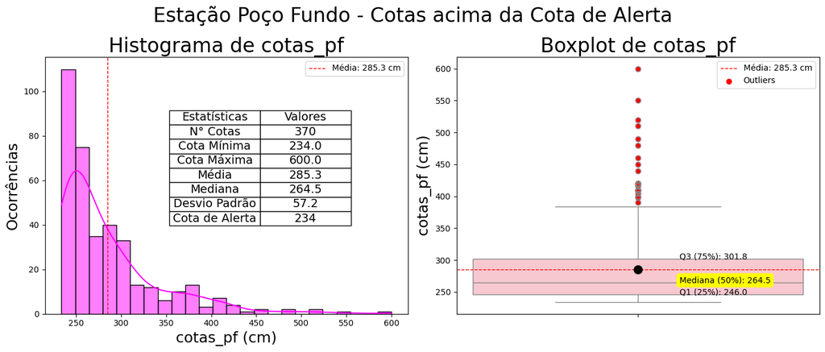

|  | data | cotas_pf |
| --- | --- | --- |
| count | 370 | 370.000000 |
| mean | 2014-04-07 04:48:00 | 285.300000 |
| min | 2000-01-16 00:00:00 | 234.000000 |
| 25% | 2011-02-02 06:00:00 | 246.000000 |
| 50% | 2014-03-15 12:00:00 | 264.500000 |
| 75% | 2016-12-26 12:00:00 | 301.750000 |
| max | 2022-12-01 00:00:00 | 600.000000 |
| std | NaN | 57.235445 |

```python
# Criação dos subplots
fig, axes = plt.subplots(1, 2, figsize=(14, 6))  # 1 linha, 2 colunas

# Histograma
sns.histplot(df_pf_max_cota_dia_periodo['cotas_pf'], ax=axes[0], kde=True, color='magenta')
axes[0].set_xlabel('cotas_pf (cm)', fontsize=18)
axes[0].set_ylabel('Ocorrências', fontsize=18)
axes[0].set_title('Histograma de cotas_pf', fontsize=24)

# Criação da Tabela:
# Calcula as estatísticas para a tabela
count = df_pf_max_cota_dia_periodo['cotas_pf'].count()
min_cota = df_pf_max_cota_dia_periodo['cotas_pf'].min()
max_cota = df_pf_max_cota_dia_periodo['cotas_pf'].max()
media = df_pf_max_cota_dia_periodo['cotas_pf'].mean()
mediana = df_pf_max_cota_dia_periodo['cotas_pf'].median()
desvio_padrao = df_pf_max_cota_dia_periodo['cotas_pf'].std()  # Calcula o desvio padrão
nivel_alerta = 234

# Dados da tabela
dados_tabela = {
    'Estatísticas': ['N° Cotas', 'Cota Mínima', 'Cota Máxima', 'Média', 'Mediana', 'Desvio Padrão', 'Cota de Alerta'],
    'Valores': [count, min_cota, max_cota, f'{media:.1f}', f'{mediana:.1f}', f'{desvio_padrao:.1f}', nivel_alerta]
}

# Cria um DataFrame para a tabela
df_tabela = pd.DataFrame(dados_tabela)

# Cria a tabela no subplot do histograma
# tabela = axes[0].table(cellText=df_tabela.values, colLabels=df_tabela.columns, loc='upper right', cellLoc='center', bbox=[0.455, 0.3425, 0.5, 0.45])
tabela = axes[0].table(cellText=df_tabela.values, colLabels=df_tabela.columns, loc='upper right', cellLoc='center', bbox=[0.3425, 0.3425, 0.5, 0.45])

# Formata a tabela (opcional)
tabela.auto_set_font_size(False)
tabela.set_fontsize(14)
tabela.scale(1, 1.5)  # Ajusta a altura das células

# Fim tabela

# Calcula e plota a média no histograma
media = df_pf_max_cota_dia_periodo['cotas_pf'].mean()
axes[0].axvline(media, color='red', linestyle='dashed', linewidth=1, label=f'Média: {media:.1f} cm')
axes[0].legend()

# Boxplot
sns.boxplot(y=df_pf_max_cota_dia_periodo['cotas_pf'], ax=axes[1], color='pink', showmeans=True, meanprops={"marker":"o",
                       "markerfacecolor":"black",
                       "markeredgecolor":"black",
                      "markersize":"10"})

# Anotações no boxplot (mediana e quartis)
mediana = df_pf_max_cota_dia_periodo['cotas_pf'].median()
q1 = df_pf_max_cota_dia_periodo['cotas_pf'].quantile(0.25)
q3 = df_pf_max_cota_dia_periodo['cotas_pf'].quantile(0.75)
iqr = q3 - q1
limite_inferior_outlier = q1 - 1.5 * iqr
limite_superior_outlier = q3 + 1.5 * iqr

axes[1].text(0.1, mediana, f'Mediana (50%): {mediana:.1f}', fontsize=10, color='black',
             bbox=dict(facecolor='yellow', edgecolor='yellow', boxstyle='round,pad=0.3'))
axes[1].text(0.1, q1, f'Q1 (25%): {q1:.1f}', fontsize=10, color='black')
axes[1].text(0.1, q3, f'Q3 (75%): {q3:.1f}', fontsize=10, color='black')

# Calcula e plota a média no boxplot
axes[1].axhline(media, color='red', linestyle='dashed', linewidth=1, label=f'Média: {media:.1f} cm')
axes[1].legend()

# Destacar outliers no boxplot
outliers = df_pf_max_cota_dia_periodo[(df_pf_max_cota_dia_periodo['cotas_pf'] < limite_inferior_outlier) | (df_pf_max_cota_dia_periodo['cotas_pf'] > limite_superior_outlier)]['cotas_pf']
axes[1].scatter(np.zeros_like(outliers), outliers, color='red', label='Outliers')
axes[1].legend()

axes[1].set_ylabel('cotas_pf (cm)', fontsize=18)
axes[1].set_title('Boxplot de cotas_pf', fontsize=24)


# Título geral do gráfico
fig.suptitle('Estação Poço Fundo - Cotas acima da Cota de Alerta', fontsize=24)

# Ajustes para melhor visualização
plt.tight_layout()

# Save the plot with specified resolution and size
plt.savefig('../output_data/images/grafico_histograma_Poco_Fundo.png', dpi=900)

# Exibição do gráfico
plt.show()

#Debug:
# análises estatísticas dos dados entre 2000 e 2022:
display(df_pf_max_cota_dia_periodo.describe())
```

#### Tratamento dos Dados de Maré

### Tratamento dos Dados de Maré

#### Arquivo: 60246008710101199431122024PREVMAXMINCOL.txt

#### Estação: CAPITANIA DOS PORTOS DE SANTA CATARINA

### Lendo o arquivo .txt e especificando a codificação:

```python
# Dados de maré fornecidos pela marinha

# Lendo o arquivo .txt com o pandas e especificando a codificação
df_mare = pd.read_csv("../input_data/60246008710101199431122024PREVMAXMINCOL.txt", delimiter='\t', encoding='ISO-8859-1')

df_mare.info()

# Exibindo as primeiras linhas do DataFrame
print(df_mare.head(20))
```

```
<class 'pandas.core.frame.DataFrame'>
RangeIndex: 60362 entries, 0 to 60361
Data columns (total 1 columns):
 #   Column                                                Non-Null Count  Dtype
---  ------                                                --------------  -----
 0   PREVISÃO MÁXIMAS E MÍNIMAS - 01/01/1994 A 31/12/2024  60362 non-null  object
dtypes: object(1)
memory usage: 471.7+ KB
   PREVISÃO MÁXIMAS E MÍNIMAS - 01/01/1994 A 31/12/2024
0                                       ESTAÇÃO:60246
1   NOME ESTAÇÃO:CAPITANIA DOS PORTOS DE SANTA CAT...
2                                LATITUDE:27º 35'.7 S
3                              LONGITUDE:048º 34'.0 W
4                                          FUSO:+03.0
5          PERÍODO DA ANÁLISE:04/10/2007 A 31/01/2008
6                                      COMPONENTES:27
7                             NÍVEL MÉDIO:0.58 METROS
8                                   ALTURAS EM METROS
9        ALTURAS ACIMA DO NÍVEL DE REDUÇÃO (NR) LOCAL
10  ESTA PREVISÃO É BASEADA EM CONSTANTES HARMÔNIC...
11                                       HORÁRIO PAPA
12                                                  #
13                              01/01/1994 00:11  0.2
14                              01/01/1994 05:02  1.0
15                              01/01/1994 10:45  0.6
16                              01/01/1994 12:53  0.5
17                              01/01/1994 17:00  1.0
18                              01/01/1994 20:56  0.3
19                              01/01/1994 22:49  0.4
```

#### Limpeza e preparação da base de dados das marés:

```python
# Excluíndo o cabeçalho que se encontra no intervalo do índice 0 até 12
df_mare = df_mare.drop(index=range(0, 13))

#Debug:
# df_mare.info()
# Exibindo o DataFrame atualizado
# display(df_mare)

# Exibindo o cabeçalho do dataframe
print(df_mare.head(10).to_markdown(index=False, numalign="left", stralign="left"))
```

```
| PREVISÃO MÁXIMAS E MÍNIMAS - 01/01/1994 A 31/12/2024   |
|:-------------------------------------------------------|
| 01/01/1994 00:11  0.2                                  |
| 01/01/1994 05:02  1.0                                  |
| 01/01/1994 10:45  0.6                                  |
| 01/01/1994 12:53  0.5                                  |
| 01/01/1994 17:00  1.0                                  |
| 01/01/1994 20:56  0.3                                  |
| 01/01/1994 22:49  0.4                                  |
| 02/01/1994 01:17  0.2                                  |
| 02/01/1994 05:41  0.9                                  |
| 02/01/1994 09:09  0.6                                  |
```

#### Ajustando a data e a hora

##### DF: *df_mare*

```python
# Separando data/hora
# Criando novas colunas com base nos caracteres específicos
df_mare['data'] = df_mare['PREVISÃO MÁXIMAS E MÍNIMAS - 01/01/1994 A 31/12/2024'].str[:10]
df_mare['hora'] = df_mare['PREVISÃO MÁXIMAS E MÍNIMAS - 01/01/1994 A 31/12/2024'].str[10:16]
df_mare['altura_mare'] = df_mare['PREVISÃO MÁXIMAS E MÍNIMAS - 01/01/1994 A 31/12/2024'].str[16:]

# Removendo a coluna original
df_mare = df_mare.drop(columns=['PREVISÃO MÁXIMAS E MÍNIMAS - 01/01/1994 A 31/12/2024'])

# Exibindo o DataFrame resultante
# display(df_mare)

# Convertendo a coluna 'data' para o tipo datetime
df_mare['data'] = pd.to_datetime(df_mare['data'], format='%d/%m/%Y')

# Removendo espaços em branco no início e no final da string da coluna 'hora'
df_mare['hora'] = df_mare['hora'].str.strip()

# Convertendo a coluna 'hora' para o tipo datetime
df_mare['hora'] = pd.to_datetime(df_mare['hora'], format='%H:%M').dt.time

# Convertendo a coluna 'altura_mare' para o tipo inteiro
df_mare['altura_mare'] = df_mare['altura_mare'].astype(float)

# DEBUG:
# Exibindo as primeiras linhas do DataFrame atualizado
# df_mare.info()

# Exibindo o cabeçalho do dataframe
print("\nDF: df_mare (PREVISÃO MÁXIMAS E MÍNIMAS - 01/01/1994 A 31/12/2024):")
print(df_mare.head(10).to_markdown(index=False, numalign="left", stralign="left"))
```

```
DF: df_mare (PREVISÃO MÁXIMAS E MÍNIMAS - 01/01/1994 A 31/12/2024):
| data                | hora     | altura_mare   |
|:--------------------|:---------|:--------------|
| 1994-01-01 00:00:00 | 00:11:00 | 0.2           |
| 1994-01-01 00:00:00 | 05:02:00 | 1             |
| 1994-01-01 00:00:00 | 10:45:00 | 0.6           |
| 1994-01-01 00:00:00 | 12:53:00 | 0.5           |
| 1994-01-01 00:00:00 | 17:00:00 | 1             |
| 1994-01-01 00:00:00 | 20:56:00 | 0.3           |
| 1994-01-01 00:00:00 | 22:49:00 | 0.4           |
| 1994-01-02 00:00:00 | 01:17:00 | 0.2           |
| 1994-01-02 00:00:00 | 05:41:00 | 0.9           |
| 1994-01-02 00:00:00 | 09:09:00 | 0.6           |
```

#### Agrupando o DataFrame pela coluna 'data' e calculando o máximo da coluna 'altura_mare' para cada dia

#### DF: *df_mare_max_cota_dia*

```python
df_mare_max_cota_dia = df_mare.groupby('data')['altura_mare'].max().reset_index()

# Exibindo o DataFrame resultante
# print(df_mare_max_cota_dia)

# Exibindo o cabeçalho do dataframe
print("\nDF df_cs_max_cota_dia (Máxima cota de maré do dia da Estação Capitana dos Portos de SC):")
# Primeiras 5 linhas
print("Primeiras 5 linhas:")
print(df_mare_max_cota_dia.head().to_markdown(index=False, numalign="left", stralign="left"))

# Últimas 5 linhas
print("\nÚltimas 5 linhas:")
print(df_mare_max_cota_dia.tail().to_markdown(index=False, numalign="left", stralign="left"))
```

```
DF df_cs_max_cota_dia (Máxima cota de maré do dia da Estação Capitana dos Portos de SC):
Primeiras 5 linhas:
| data                | altura_mare   |
|:--------------------|:--------------|
| 1994-01-01 00:00:00 | 1             |
| 1994-01-02 00:00:00 | 0.9           |
| 1994-01-03 00:00:00 | 0.9           |
| 1994-01-04 00:00:00 | 0.9           |
| 1994-01-05 00:00:00 | 0.9           |

Últimas 5 linhas:
| data                | altura_mare   |
|:--------------------|:--------------|
| 2024-12-27 00:00:00 | 0.9           |
| 2024-12-28 00:00:00 | 1             |
| 2024-12-29 00:00:00 | 1             |
| 2024-12-30 00:00:00 | 1.1           |
| 2024-12-31 00:00:00 | 1.1           |
```

##### DF: *df_mare_max_cota_dia_periodo*

```python
df_mare_max_cota_dia_periodo = df_mare_max_cota_dia[(df_mare_max_cota_dia['data'] >= '2000-01-01') & (df_mare_max_cota_dia['data'] <= '2022-12-31')]

# print(df_mare_max_cota_dia_periodo)
# Exibindo o cabeçalho do dataframe
print("\nDF df_mare_max_cota_dia_periodo (Máxima cota de maré do dia da Estação Capitana dos Portos de SC):")
# Primeiras 5 linhas
print("Primeiras 5 linhas:")
print(df_mare_max_cota_dia_periodo.head().to_markdown(index=False, numalign="left", stralign="left"))

# Últimas 5 linhas
print("\nÚltimas 5 linhas:")
print(df_mare_max_cota_dia_periodo.tail().to_markdown(index=False, numalign="left", stralign="left"))

# Salva do DataFrame Eta casasn cota máxima do dia de todo banco dados.
df_mare_max_cota_dia_periodo.to_csv('../output_data/database/df_mare_max_cota_dia_periodo.csv')
```

```
DF df_mare_max_cota_dia_periodo (Máxima cota de maré do dia da Estação Capitana dos Portos de SC):
Primeiras 5 linhas:
| data                | altura_mare   |
|:--------------------|:--------------|
| 2000-01-01 00:00:00 | 0.9           |
| 2000-01-02 00:00:00 | 0.9           |
| 2000-01-03 00:00:00 | 0.9           |
| 2000-01-04 00:00:00 | 1             |
| 2000-01-05 00:00:00 | 1             |

Últimas 5 linhas:
| data                | altura_mare   |
|:--------------------|:--------------|
| 2022-12-27 00:00:00 | 0.9           |
| 2022-12-28 00:00:00 | 0.9           |
| 2022-12-29 00:00:00 | 0.9           |
| 2022-12-30 00:00:00 | 0.9           |
| 2022-12-31 00:00:00 | 0.9           |
```

### Tratando os mapas e bacia hidrográficas

### Tratando os mapas e bacia hidrográficas

### Abrindo um arquivo NETCDF

#### Arquivo: MERGE_CPTEC_DAILY_PREC_SC_2000_2022.nc

```python
# Caminho para o arquivo NetCDF
caminho_arquivo = r'../input_data/MERGE_CPTEC_DAILY_PREC_SC_2000_2022.nc'

# Abre o arquivo NetCDF para leitura
arquivo_netcdf = nc.Dataset(caminho_arquivo)
print(arquivo_netcdf.variables.keys())

# Seleciona a variável "precipitacao"
variavel_precipitacao = arquivo_netcdf.variables['prec']
variavel_latitudes=arquivo_netcdf.variables['lat']
variavel_longitudes=arquivo_netcdf.variables['lon']
variavel_tempos=arquivo_netcdf.variables['time']

# Lê os dados da variável de precipitação
prec_data = variavel_precipitacao[:]
latitudes = variavel_latitudes[:]
longitudes = variavel_longitudes[:]
tempos=variavel_tempos[:]
```

```
dict_keys(['time', 'lon', 'lat', 'prec'])
```

### Associando as variáveis trazidas do NetCdf a um DataFrame

```python
# Obtém as dimensões dos dados
time_dim = prec_data.shape[0]
lat_dim = prec_data.shape[1]
lon_dim = prec_data.shape[2]

# Cria os índices de tempo, latitude e longitude
index_time = pd.date_range(start='2000-01-01', periods=time_dim, freq='D')
index_lat = range(lat_dim)
index_lon = range(lon_dim)

# Cria o DataFrame
df_prec = pd.DataFrame(prec_data.reshape((time_dim, -1)),
                        index=index_time,
                        columns=pd.MultiIndex.from_product([index_lat, index_lon], names=['lon', 'lat']))

df_prec = df_prec.rename_axis('data')


# Mostra as primeiras linhas do DataFrame
#print(df_prec.head())


# Salva o DataFrame em um arquivo CSV
df_prec.to_csv(r'../output_data/database/dadosB_precipitacao.csv')

# Supondo que index_lon, index_lat e index_time estão definidos
dados_empilhados = []  # Inicializa uma lista vazia para armazenar os dados

for i in index_lon:
    for j in index_lat:
        # Supondo que df_prec é seu DataFrame original
        # Adiciona os dados de df_prec[i][j][index_time] à lista dados_empilhados
        dados_empilhados.append(df_prec[j][i][index_time])

# Crie o DataFrame a partir dos dados empilhados
dfEmpilhado = pd.concat(dados_empilhados, axis=1, keys=[f'Lon_{longitudes[i].round(2)} Lat_{latitudes[j].round(2)}' for i in index_lon for j in index_lat])

# Verifica as primeiras linhas do DataFrame empilhado
print("DF: dfEmpilhado:")
dfEmpilhado.head()
```

```
DF: dfEmpilhado:
```

|  | Lon_-53.95 Lat_-29.65 | Lon_-53.95 Lat_-29.55 | Lon_-53.95 Lat_-29.45 | Lon_-53.95 Lat_-29.35 | Lon_-53.95 Lat_-29.25 | Lon_-53.95 Lat_-29.15 | Lon_-53.95 Lat_-29.05 | Lon_-53.95 Lat_-28.95 | Lon_-53.95 Lat_-28.85 | Lon_-53.95 Lat_-28.75 | ... | Lon_-48.05 Lat_-26.45 | Lon_-48.05 Lat_-26.35 | Lon_-48.05 Lat_-26.25 | Lon_-48.05 Lat_-26.15 | Lon_-48.05 Lat_-26.05 | Lon_-48.05 Lat_-25.95 | Lon_-48.05 Lat_-25.85 | Lon_-48.05 Lat_-25.75 | Lon_-48.05 Lat_-25.65 | Lon_-48.05 Lat_-25.55 |
| --- | --- | --- | --- | --- | --- | --- | --- | --- | --- | --- | --- | --- | --- | --- | --- | --- | --- | --- | --- | --- | --- |
| 2000-01-01 | 0.00 | 0.00 | 0.000 | 0.00 | 0.00 | 0.000 | 0.000 | 0.00 | 0.000 | 0.000 | ... | 0.0 | 0.0 | 0.0 | 0.0 | 0.0 | 0.0 | 0.0 | 0.000 | 0.000 | 0.00 |
| 2000-01-02 | 0.00 | 0.00 | 0.000 | 0.00 | 0.00 | 0.000 | 0.000 | 0.00 | 0.000 | 0.000 | ... | 0.0 | 0.0 | 0.0 | 0.0 | 0.0 | 0.0 | 0.0 | 0.125 | 0.125 | 0.00 |
| 2000-01-03 | 0.25 | 0.25 | 0.500 | 0.75 | 0.75 | 1.250 | 1.250 | 0.75 | 0.250 | 0.250 | ... | 0.0 | 0.0 | 0.0 | 0.0 | 0.0 | 0.0 | 0.0 | 0.000 | 0.250 | 0.25 |
| 2000-01-04 | 11.00 | 9.75 | 7.750 | 0.00 | 2.50 | 1.250 | 0.750 | 0.00 | 0.500 | 1.750 | ... | 0.0 | 0.0 | 0.0 | 0.0 | 0.0 | 0.0 | 0.0 | 0.000 | 0.000 | 0.00 |
| 2000-01-05 | 54.25 | 55.75 | 62.375 | 74.25 | 57.75 | 36.875 | 21.125 | 16.00 | 15.375 | 23.875 | ... | 0.0 | 0.0 | 0.0 | 0.0 | 0.0 | 0.0 | 0.0 | 0.000 | 0.000 | 0.00 |

5 rows × 2520 columns

```python
# Renomeando o dataframe:
df_precipitacao_bacia = dfEmpilhado
df_precipitacao_bacia.columns
```

```
Index(['Lon_-53.95 Lat_-29.65', 'Lon_-53.95 Lat_-29.55',
       'Lon_-53.95 Lat_-29.45', 'Lon_-53.95 Lat_-29.35',
       'Lon_-53.95 Lat_-29.25', 'Lon_-53.95 Lat_-29.15',
       'Lon_-53.95 Lat_-29.05', 'Lon_-53.95 Lat_-28.95',
       'Lon_-53.95 Lat_-28.85', 'Lon_-53.95 Lat_-28.75',
       ...
       'Lon_-48.05 Lat_-26.45', 'Lon_-48.05 Lat_-26.35',
       'Lon_-48.05 Lat_-26.25', 'Lon_-48.05 Lat_-26.15',
       'Lon_-48.05 Lat_-26.05', 'Lon_-48.05 Lat_-25.95',
       'Lon_-48.05 Lat_-25.85', 'Lon_-48.05 Lat_-25.75',
       'Lon_-48.05 Lat_-25.65', 'Lon_-48.05 Lat_-25.55'],
      dtype='object', length=2520)
```

#### Definindo as coordenadas que estão dentro da Bacia Hidrográfica do Rio Cubatão do Sul - SC

```python
coordenadas_bacia_cubatao_sul = [
    'Lon_-48.95 Lat_-27.75',
    'Lon_-48.95 Lat_-27.65',
    'Lon_-48.85 Lat_-27.85',
    'Lon_-48.85 Lat_-27.65',
    'Lon_-48.75 Lat_-27.75',
    'Lon_-48.75 Lat_-27.65',
    'Lon_-48.65 Lat_-27.55',
    'Lon_-48.55 Lat_-27.65',
    'Lon_-48.45 Lat_-27.55',
    'Lon_-48.45 Lat_-27.45'
]

# ponto excluído da bacia - vargem do braço (-27.75, -48.55),  por estar após a estação ETA casan montante.

print("DF: df_precipitacao_bacia:")
df_precipitacao_bacia[coordenadas_bacia_cubatao_sul]
display(df_precipitacao_bacia[coordenadas_bacia_cubatao_sul])
```

```
DF: df_precipitacao_bacia:
```

|  | Lon_-48.95 Lat_-27.75 | Lon_-48.95 Lat_-27.65 | Lon_-48.85 Lat_-27.85 | Lon_-48.85 Lat_-27.65 | Lon_-48.75 Lat_-27.75 | Lon_-48.75 Lat_-27.65 | Lon_-48.65 Lat_-27.55 | Lon_-48.55 Lat_-27.65 | Lon_-48.45 Lat_-27.55 | Lon_-48.45 Lat_-27.45 |
| --- | --- | --- | --- | --- | --- | --- | --- | --- | --- | --- |
| 2000-01-01 | 0.0000 | 0.0000 | 0.0000 | 0.000 | 0.0000 | 0.0000 | 0.0000 | 0.0000 | 0.000 | 0.0000 |
| 2000-01-02 | 0.0000 | 0.0000 | 0.0000 | 0.000 | 0.0000 | 0.0000 | 0.0000 | 0.0000 | 0.000 | 0.0000 |
| 2000-01-03 | 0.0000 | 0.0000 | 0.0000 | 0.000 | 0.0000 | 0.0000 | 0.0000 | 0.0000 | 0.000 | 0.0000 |
| 2000-01-04 | 3.7500 | 4.7500 | 1.2500 | 2.250 | 3.0000 | 3.5000 | 2.2500 | 2.2500 | 1.500 | 2.0000 |
| 2000-01-05 | 2.6250 | 3.1250 | 2.5000 | 2.375 | 3.1250 | 2.8750 | 1.5000 | 0.5000 | 0.750 | 0.3750 |
| ... | ... | ... | ... | ... | ... | ... | ... | ... | ... | ... |
| 2022-07-27 | 5.8750 | 6.1250 | 4.1250 | 4.625 | 4.5000 | 4.0000 | 1.7500 | 0.1250 | 2.125 | 10.5000 |
| 2022-07-28 | 7.6250 | 7.7500 | 6.0625 | 6.250 | 5.9375 | 5.1250 | 4.6875 | 5.0000 | 5.875 | 9.2500 |
| 2022-07-29 | 23.9375 | 28.1250 | 20.8125 | 27.000 | 22.8750 | 24.7500 | 43.1250 | 31.9375 | 38.625 | 34.3125 |
| 2022-07-30 | 2.1875 | 4.9375 | 0.8125 | 1.625 | 0.4375 | 0.3125 | 0.0000 | 0.0000 | 0.000 | 0.0000 |
| 2022-07-31 | 0.0000 | 0.0000 | 0.0000 | 0.000 | 0.0000 | 0.0000 | 0.0000 | 0.0000 | 0.000 | 0.0000 |

8248 rows × 10 columns

#### Criando uma lista para armazenar os resultados

```python
# Criando uma lista para armazenar os resultados
resultados = []

# Percorra as linhas do DataFrame
for indice, linha in df_precipitacao_bacia.iterrows():
    # Mantenha o índice como "data"
    data = indice

    # Some todas as colunas para a linha atual
    soma_linha = linha.sum()

    # Adicione a soma à lista de resultados
    resultados.append({'data': data, 'soma': soma_linha})

# Converta a lista de resultados em um DataFrame
df_precipitacao_bacia_total_dia = pd.DataFrame(resultados)
df_precipitacao_bacia_total_dia = df_precipitacao_bacia_total_dia.rename(columns={'soma': 'precipitacao'})

# Exiba o DataFrame resultante
print("DF: df_precipitacao_bacia_total_dia:")
display(df_precipitacao_bacia_total_dia)
```

```
DF: df_precipitacao_bacia_total_dia:
```

|  | data | precipitacao |
| --- | --- | --- |
| 0 | 2000-01-01 | 296.0000 |
| 1 | 2000-01-02 | 207.7500 |
| 2 | 2000-01-03 | 1187.7500 |
| 3 | 2000-01-04 | 17357.0000 |
| 4 | 2000-01-05 | 31482.6250 |
| ... | ... | ... |
| 8243 | 2022-07-27 | 1591.0000 |
| 8244 | 2022-07-28 | 37311.3125 |
| 8245 | 2022-07-29 | 6367.2500 |
| 8246 | 2022-07-30 | 233.1250 |
| 8247 | 2022-07-31 | 300.2500 |

8248 rows × 2 columns

#### Calculando as precipitações acumuladas (Semanal, 14 dias, 21 dias, 28 dias e 1 mês)

```python
# Converta a coluna 'data' para o tipo datetime, se ainda não estiver
df_precipitacao_bacia_total_dia['data'] = pd.to_datetime(df_precipitacao_bacia_total_dia['data'])

# Ordene o DataFrame pela coluna 'data' se ainda não estiver ordenado
df_precipitacao_bacia_total_dia = df_precipitacao_bacia_total_dia.sort_values(by='data')

# Calcule a soma acumulada dos 7 dias anteriores e desloque os valores para representar os 7 dias anteriores
df_precipitacao_bacia_total_dia['d-7'] = df_precipitacao_bacia_total_dia['precipitacao'].rolling(window=7).sum().shift(periods=1)

# Calcule a soma acumulada dos 14 dias anteriores e desloque os valores para representar os 14 dias anteriores
df_precipitacao_bacia_total_dia['d-14'] = df_precipitacao_bacia_total_dia['precipitacao'].rolling(window=14).sum().shift(periods=1)

# Calcule a soma acumulada dos 21 dias anteriores e desloque os valores para representar os 21 dias anteriores
df_precipitacao_bacia_total_dia['d-21'] = df_precipitacao_bacia_total_dia['precipitacao'].rolling(window=21).sum().shift(periods=1)

# Calcule a soma acumulada dos 28 dias anteriores e desloque os valores para representar os 28 dias anteriores
df_precipitacao_bacia_total_dia['d-28'] = df_precipitacao_bacia_total_dia['precipitacao'].rolling(window=28).sum().shift(periods=1)

# Calcule a soma acumulada dos 30 dias anteriores e desloque os valores para representar os 30 dias anteriores
df_precipitacao_bacia_total_dia['d-30'] = df_precipitacao_bacia_total_dia['precipitacao'].rolling(window=30).sum().shift(periods=1)

# Exiba o DataFrame resultante
print("DF: df_precipitacao_bacia_total_dia:")
display(df_precipitacao_bacia_total_dia)
```

```
DF: df_precipitacao_bacia_total_dia:
```

|  | data | precipitacao | d-7 | d-14 | d-21 | d-28 | d-30 |
| --- | --- | --- | --- | --- | --- | --- | --- |
| 0 | 2000-01-01 | 296.0000 | NaN | NaN | NaN | NaN | NaN |
| 1 | 2000-01-02 | 207.7500 | NaN | NaN | NaN | NaN | NaN |
| 2 | 2000-01-03 | 1187.7500 | NaN | NaN | NaN | NaN | NaN |
| 3 | 2000-01-04 | 17357.0000 | NaN | NaN | NaN | NaN | NaN |
| 4 | 2000-01-05 | 31482.6250 | NaN | NaN | NaN | NaN | NaN |
| ... | ... | ... | ... | ... | ... | ... | ... |
| 8243 | 2022-07-27 | 1591.0000 | 79471.4375 | 164827.375 | 194923.0625 | 350439.5625 | 397780.5625 |
| 8244 | 2022-07-28 | 37311.3125 | 38453.3125 | 126175.875 | 187690.3125 | 338043.5625 | 369105.5625 |
| 8245 | 2022-07-29 | 6367.2500 | 60297.5000 | 163315.750 | 219544.8750 | 362552.5000 | 389341.8750 |
| 8246 | 2022-07-30 | 233.1250 | 64192.7500 | 169655.500 | 225720.0000 | 319957.2500 | 381722.1250 |
| 8247 | 2022-07-31 | 300.2500 | 64291.2500 | 168082.500 | 225318.2500 | 310286.8750 | 369152.8750 |

8248 rows × 7 columns

```python
# Estatísticas para a conferência
df_precipitacao_bacia_total_dia.info()
```

```
<class 'pandas.core.frame.DataFrame'>
RangeIndex: 8248 entries, 0 to 8247
Data columns (total 7 columns):
 #   Column        Non-Null Count  Dtype
---  ------        --------------  -----
 0   data          8248 non-null   datetime64[ns]
 1   precipitacao  8248 non-null   float32
 2   d-7           8241 non-null   float64
 3   d-14          8234 non-null   float64
 4   d-21          8227 non-null   float64
 5   d-28          8220 non-null   float64
 6   d-30          8218 non-null   float64
dtypes: datetime64[ns](1), float32(1), float64(5)
memory usage: 419.0 KB
```

#### Concatenando os DataFrames com base na coluna 'data'

```python
# Concatenando os DataFrames com base na coluna 'data'
df_dados_resumo = pd.concat([df_cs_max_cota_dia_periodo, df_pf_max_cota_dia_periodo ,df_mare_max_cota_dia_periodo, df_precipitacao_bacia_total_dia], ignore_index=True)

print("Exibindo o cabeçalho do dataframe resultante:")
# Primeiras 5 linhas
print("Primeiras 5 linhas:")
print(df_dados_resumo.head(100).to_markdown(index=False, numalign="left", stralign="left"))

# Últimas 5 linhas
print("\nÚltimas 5 linhas:")
print(df_dados_resumo.tail(100).to_markdown(index=False, numalign="left", stralign="left"))
```

```
Exibindo o cabeçalho do dataframe resultante:
Primeiras 5 linhas:
| data                | cotas_cs   | cotas_pf   | altura_mare   | precipitacao   | d-7   | d-14   | d-21   | d-28   | d-30   |
|:--------------------|:-----------|:-----------|:--------------|:---------------|:------|:-------|:-------|:-------|:-------|
| 2000-01-11 00:00:00 | 266        | nan        | nan           | nan            | nan   | nan    | nan    | nan    | nan    |
| 2000-01-12 00:00:00 | 305        | nan        | nan           | nan            | nan   | nan    | nan    | nan    | nan    |
| 2000-01-14 00:00:00 | 287        | nan        | nan           | nan            | nan   | nan    | nan    | nan    | nan    |
| 2000-01-15 00:00:00 | 256        | nan        | nan           | nan            | nan   | nan    | nan    | nan    | nan    |
| 2000-01-16 00:00:00 | 276        | nan        | nan           | nan            | nan   | nan    | nan    | nan    | nan    |
| 2000-01-17 00:00:00 | 298        | nan        | nan           | nan            | nan   | nan    | nan    | nan    | nan    |
| 2000-02-14 00:00:00 | 310        | nan        | nan           | nan            | nan   | nan    | nan    | nan    | nan    |
| 2000-02-15 00:00:00 | 325        | nan        | nan           | nan            | nan   | nan    | nan    | nan    | nan    |
| 2000-02-16 00:00:00 | 278        | nan        | nan           | nan            | nan   | nan    | nan    | nan    | nan    |
| 2000-03-06 00:00:00 | 510        | nan        | nan           | nan            | nan   | nan    | nan    | nan    | nan    |
| 2001-02-04 00:00:00 | 558        | nan        | nan           | nan            | nan   | nan    | nan    | nan    | nan    |
| 2001-02-05 00:00:00 | 522        | nan        | nan           | nan            | nan   | nan    | nan    | nan    | nan    |
| 2001-02-06 00:00:00 | 286        | nan        | nan           | nan            | nan   | nan    | nan    | nan    | nan    |
| 2001-02-19 00:00:00 | 329        | nan        | nan           | nan            | nan   | nan    | nan    | nan    | nan    |
| 2001-02-28 00:00:00 | 368        | nan        | nan           | nan            | nan   | nan    | nan    | nan    | nan    |
| 2001-03-06 00:00:00 | 312        | nan        | nan           | nan            | nan   | nan    | nan    | nan    | nan    |
| 2001-05-04 00:00:00 | 368        | nan        | nan           | nan            | nan   | nan    | nan    | nan    | nan    |
| 2001-05-28 00:00:00 | 352        | nan        | nan           | nan            | nan   | nan    | nan    | nan    | nan    |
| 2001-06-25 00:00:00 | 358        | nan        | nan           | nan            | nan   | nan    | nan    | nan    | nan    |
| 2001-06-26 00:00:00 | 256        | nan        | nan           | nan            | nan   | nan    | nan    | nan    | nan    |
| 2001-07-20 00:00:00 | 296        | nan        | nan           | nan            | nan   | nan    | nan    | nan    | nan    |
| 2001-09-23 00:00:00 | 500        | nan        | nan           | nan            | nan   | nan    | nan    | nan    | nan    |
| 2001-09-24 00:00:00 | 331        | nan        | nan           | nan            | nan   | nan    | nan    | nan    | nan    |
| 2001-09-30 00:00:00 | 607        | nan        | nan           | nan            | nan   | nan    | nan    | nan    | nan    |
| 2001-10-01 00:00:00 | 688        | nan        | nan           | nan            | nan   | nan    | nan    | nan    | nan    |
| 2001-10-02 00:00:00 | 264        | nan        | nan           | nan            | nan   | nan    | nan    | nan    | nan    |
| 2001-10-08 00:00:00 | 345        | nan        | nan           | nan            | nan   | nan    | nan    | nan    | nan    |
| 2001-10-09 00:00:00 | 291        | nan        | nan           | nan            | nan   | nan    | nan    | nan    | nan    |
| 2001-11-11 00:00:00 | 229        | nan        | nan           | nan            | nan   | nan    | nan    | nan    | nan    |
| 2001-12-14 00:00:00 | 263        | nan        | nan           | nan            | nan   | nan    | nan    | nan    | nan    |
| 2001-12-23 00:00:00 | 243        | nan        | nan           | nan            | nan   | nan    | nan    | nan    | nan    |
| 2002-01-10 00:00:00 | 216        | nan        | nan           | nan            | nan   | nan    | nan    | nan    | nan    |
| 2002-01-12 00:00:00 | 256        | nan        | nan           | nan            | nan   | nan    | nan    | nan    | nan    |
| 2002-01-13 00:00:00 | 286        | nan        | nan           | nan            | nan   | nan    | nan    | nan    | nan    |
| 2002-08-06 00:00:00 | 228        | nan        | nan           | nan            | nan   | nan    | nan    | nan    | nan    |
| 2002-10-30 00:00:00 | 276        | nan        | nan           | nan            | nan   | nan    | nan    | nan    | nan    |
```

[output cut: 153 more lines]

```
| 2022-07-17 00:00:00 | nan        | nan        | nan           | 5771.5         | 57235.8 | 142204  | 278052  | 314214 | 315421 |
| 2022-07-18 00:00:00 | nan        | nan        | nan           | 8844.75        | 59615.8 | 127264  | 280972  | 319983 | 321190 |
| 2022-07-19 00:00:00 | nan        | nan        | nan           | 28492.1        | 62526.7 | 123738  | 259551  | 328761 | 328830 |
| 2022-07-20 00:00:00 | nan        | nan        | nan           | 42609.1        | 85355.9 | 115452  | 270968  | 357229 | 357320 |
| 2022-07-21 00:00:00 | nan        | nan        | nan           | 15467.1        | 87722.6 | 149237  | 299590  | 381816 | 399863 |
| 2022-07-22 00:00:00 | nan        | nan        | nan           | 2472           | 103018  | 159247  | 302255  | 383725 | 415305 |
| 2022-07-23 00:00:00 | nan        | nan        | nan           | 134.625        | 105463  | 161527  | 255764  | 381930 | 399755 |
| 2022-07-24 00:00:00 | nan        | nan        | nan           | 351.25         | 103791  | 161027  | 245996  | 381843 | 386331 |
| 2022-07-25 00:00:00 | nan        | nan        | nan           | 686.75         | 98371   | 157987  | 225636  | 379343 | 382416 |
| 2022-07-26 00:00:00 | nan        | nan        | nan           | 17750.6        | 90213   | 152740  | 213951  | 349764 | 382881 |
| 2022-07-27 00:00:00 | nan        | nan        | nan           | 1591           | 79471.4 | 164827  | 194923  | 350440 | 397781 |
| 2022-07-28 00:00:00 | nan        | nan        | nan           | 37311.3        | 38453.3 | 126176  | 187690  | 338044 | 369106 |
| 2022-07-29 00:00:00 | nan        | nan        | nan           | 6367.25        | 60297.5 | 163316  | 219545  | 362552 | 389342 |
| 2022-07-30 00:00:00 | nan        | nan        | nan           | 233.125        | 64192.8 | 169656  | 225720  | 319957 | 381722 |
| 2022-07-31 00:00:00 | nan        | nan        | nan           | 300.25         | 64291.2 | 168082  | 225318  | 310287 | 369153 |
```

#### Unindo os DataFrames usando o método merge

```python
# Unindo os DataFrames usando o método merge
df_dados_resumo = df_cs_max_cota_dia_periodo.merge(df_pf_max_cota_dia_periodo, on='data', how='outer') \
    .merge(df_mare_max_cota_dia_periodo, on='data', how='outer') \
    .merge(df_precipitacao_bacia_total_dia, on='data', how='outer')

# Resetando o índice do DataFrame
df_dados_resumo = df_dados_resumo.reset_index(drop=True)

#df_dados_resumo
# Exibindo o cabeçalho do dataframe
# Primeiras 5 linhas
print("Primeiras 5 linhas:")
print(df_dados_resumo.head().to_markdown(index=False, numalign="left", stralign="left"))

# Últimas 5 linhas
print("\nÚltimas 5 linhas:")
print(df_dados_resumo.tail().to_markdown(index=False, numalign="left", stralign="left"))
```

```
Primeiras 5 linhas:
| data                | cotas_cs   | cotas_pf   | altura_mare   | precipitacao   | d-7   | d-14   | d-21   | d-28   | d-30   |
|:--------------------|:-----------|:-----------|:--------------|:---------------|:------|:-------|:-------|:-------|:-------|
| 2000-01-01 00:00:00 | nan        | nan        | 0.9           | 296            | nan   | nan    | nan    | nan    | nan    |
| 2000-01-02 00:00:00 | nan        | nan        | 0.9           | 207.75         | nan   | nan    | nan    | nan    | nan    |
| 2000-01-03 00:00:00 | nan        | nan        | 0.9           | 1187.75        | nan   | nan    | nan    | nan    | nan    |
| 2000-01-04 00:00:00 | nan        | nan        | 1             | 17357          | nan   | nan    | nan    | nan    | nan    |
| 2000-01-05 00:00:00 | nan        | nan        | 1             | 31482.6        | nan   | nan    | nan    | nan    | nan    |

Últimas 5 linhas:
| data                | cotas_cs   | cotas_pf   | altura_mare   | precipitacao   | d-7   | d-14   | d-21   | d-28   | d-30   |
|:--------------------|:-----------|:-----------|:--------------|:---------------|:------|:-------|:-------|:-------|:-------|
| 2022-12-27 00:00:00 | nan        | nan        | 0.9           | nan            | nan   | nan    | nan    | nan    | nan    |
| 2022-12-28 00:00:00 | 250        | nan        | 0.9           | nan            | nan   | nan    | nan    | nan    | nan    |
| 2022-12-29 00:00:00 | nan        | nan        | 0.9           | nan            | nan   | nan    | nan    | nan    | nan    |
| 2022-12-30 00:00:00 | nan        | nan        | 0.9           | nan            | nan   | nan    | nan    | nan    | nan    |
| 2022-12-31 00:00:00 | nan        | nan        | 0.9           | nan            | nan   | nan    | nan    | nan    | nan    |
```

#### Salvando Dataframes em um arquivo csv

```python
# Salvando o DataFrame df_dados_resumo em um arquivo CSV
df_dados_resumo.to_csv(r'../output_data/database/dados_resumo.csv', index=False)
```

#### Debug de testes

```python
# Checando os tipos de variáveis
x = pd.read_csv('../output_data/database/dados_resumo.csv')
x.info()
```

```
<class 'pandas.core.frame.DataFrame'>
RangeIndex: 8401 entries, 0 to 8400
Data columns (total 10 columns):
 #   Column        Non-Null Count  Dtype
---  ------        --------------  -----
 0   data          8401 non-null   object
 1   cotas_cs      287 non-null    float64
 2   cotas_pf      370 non-null    float64
 3   altura_mare   8401 non-null   float64
 4   precipitacao  8248 non-null   float64
 5   d-7           8241 non-null   float64
 6   d-14          8234 non-null   float64
 7   d-21          8227 non-null   float64
 8   d-28          8220 non-null   float64
 9   d-30          8218 non-null   float64
dtypes: float64(9), object(1)
memory usage: 656.5+ KB
```

```python
# Contagem de dados em cada coluna
contagem_por_coluna = df_dados_resumo.count()
print("Quantidade de dados em cada coluna:")
print(contagem_por_coluna)
```

```
Quantidade de dados em cada coluna:
data            8401
cotas_cs         287
cotas_pf         370
altura_mare     8401
precipitacao    8248
d-7             8241
d-14            8234
d-21            8227
d-28            8220
d-30            8218
dtype: int64
```

```python
# Inicial e final de cada coluna com dados
inicial_final_por_coluna = {}

# Iterar sobre cada coluna
for coluna in df_dados_resumo.columns:
    # Encontrar o índice do primeiro valor não nulo na coluna
    indice_inicial = df_dados_resumo[coluna].first_valid_index()

    # Encontrar o índice do último valor não nulo na coluna
    indice_final = df_dados_resumo[coluna].last_valid_index()

    # Adicionar os índices inicial e final à lista
    inicial_final_por_coluna[coluna] = (indice_inicial, indice_final)

# Exibir os resultados
print("Inicial e final de cada coluna com dados:")
for coluna, (indice_inicial, indice_final) in inicial_final_por_coluna.items():
    print(f"{coluna}: Inicial - {indice_inicial}, Final - {indice_final}")
```

```
Inicial e final de cada coluna com dados:
data: Inicial - 0, Final - 8400
cotas_cs: Inicial - 10, Final - 8397
cotas_pf: Inicial - 15, Final - 8370
altura_mare: Inicial - 0, Final - 8400
precipitacao: Inicial - 0, Final - 8247
d-7: Inicial - 7, Final - 8247
d-14: Inicial - 14, Final - 8247
d-21: Inicial - 21, Final - 8247
d-28: Inicial - 28, Final - 8247
d-30: Inicial - 30, Final - 8247
```

```python
# Inicial e final de cada coluna com dados
inicial_final_por_coluna = {}

# Iterar sobre cada coluna
for coluna in df_dados_resumo.columns:
    # Encontrar o índice do primeiro valor não nulo na coluna
    indice_inicial = df_dados_resumo[coluna].first_valid_index()
    # Converter o índice inicial para o formato de data
    data_inicial = df_dados_resumo.loc[indice_inicial, 'data'].strftime('%d/%m/%Y') if indice_inicial is not None else None

    # Encontrar o índice do último valor não nulo na coluna
    indice_final = df_dados_resumo[coluna].last_valid_index()
    # Converter o índice final para o formato de data
    data_final = df_dados_resumo.loc[indice_final, 'data'].strftime('%d/%m/%Y') if indice_final is not None else None

    # Adicionar as datas inicial e final à lista
    inicial_final_por_coluna[coluna] = (data_inicial, data_final)

# Exibir os resultados
print("Inicial e final de cada coluna com dados:")
for coluna, (data_inicial, data_final) in inicial_final_por_coluna.items():

    display(f"{coluna}: Inicial - {data_inicial}, Final - {data_final}")
```

```
Inicial e final de cada coluna com dados:
```

```
'data: Inicial - 01/01/2000, Final - 31/12/2022'
```

```
'cotas_cs: Inicial - 11/01/2000, Final - 28/12/2022'
```

```
'cotas_pf: Inicial - 16/01/2000, Final - 01/12/2022'
```

```
'altura_mare: Inicial - 01/01/2000, Final - 31/12/2022'
```

```
'precipitacao: Inicial - 01/01/2000, Final - 31/07/2022'
```

```
'd-7: Inicial - 08/01/2000, Final - 31/07/2022'
```

```
'd-14: Inicial - 15/01/2000, Final - 31/07/2022'
```

```
'd-21: Inicial - 22/01/2000, Final - 31/07/2022'
```

```
'd-28: Inicial - 29/01/2000, Final - 31/07/2022'
```

```
'd-30: Inicial - 31/01/2000, Final - 31/07/2022'
```

#### Plotando os Mapas com as coordenadas

#### Abre o Shapefile Brasil Chama coordenadas no estado do NETCDF e plota ambos:

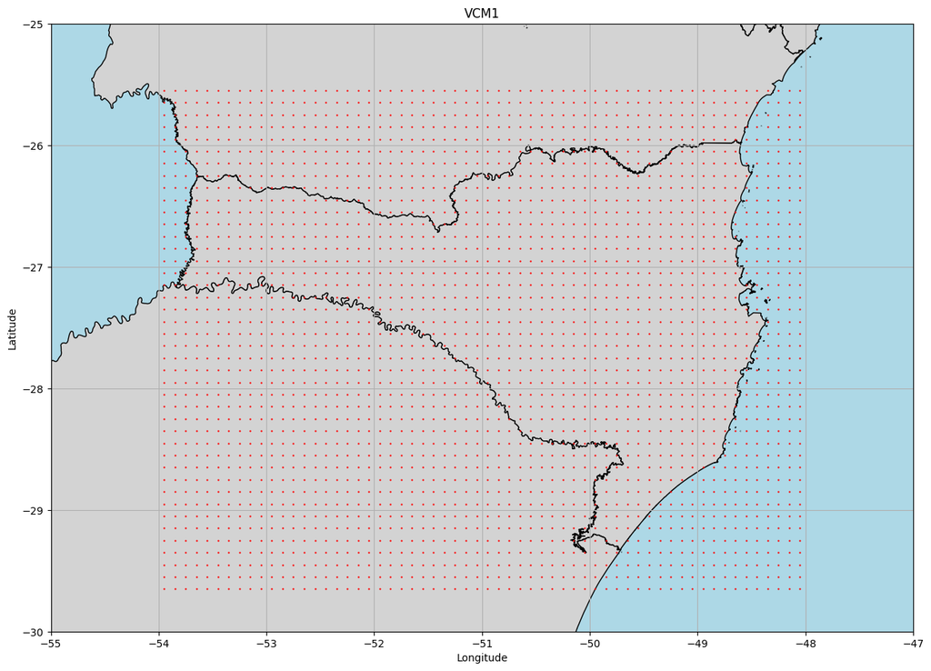

```python
import geopandas as gpd
import matplotlib.pyplot as plt
from shapely.geometry import Point, Polygon
import itertools
import pandas as pd

# Lendo o shapefile do Brasil
br = gpd.read_file(r'../input_data/shape_files/BR_UF_2022.shp')

# Gerando todas as combinações de latitudes e longitudes
combinacoes = list(itertools.product(latitudes, longitudes))

# Criando um DataFrame com as combinações de latitudes e longitudes
df_pontos = pd.DataFrame(combinacoes, columns=['lon', 'lat'])

# Criando o GeoDataFrame com os pontos
geometry = [Point(xy) for xy in zip(df_pontos['lat'], df_pontos['lon'])]
vcm1 = gpd.GeoDataFrame(df_pontos, geometry=geometry, crs="EPSG:4674")

# Plotando o mapa
fig, ax = plt.subplots(figsize = (15, 12))
coord_atlantico = [(-90, -40),(-30, -40),
	               (-30, 10),(-90, 10)]
atlantico_poly = Polygon(coord_atlantico)
atlantico = gpd.GeoDataFrame(geometry = [atlantico_poly])
atlantico.plot(ax = ax, color = "lightblue") # atlantico ~ base
ax.set_aspect("auto")

# Adicionando o shapefile do Brasil ao plot
br.plot(ax=ax, color='lightgrey', edgecolor='black')

# Plotando os pontos
vcm1.plot(ax=ax, color='red', markersize=0.5)


# Configurando o título e os rótulos dos eixos
plt.xlabel('Longitude')
plt.ylabel('Latitude')
plt.title('Pontos sobre o Mapa do Brasil')
plt.xlim(-55, -47)
plt.ylim(-30, -25)
plt.xlabel("Longitude")
plt.ylabel("Latitude")
plt.title(f"VCM1")
plt.grid(True)
plt.savefig('../output_data/images/GraficoPontosSobreoMapadoBrasil.png', dpi=900, bbox_inches='tight')

# Exibindo o gráfico
plt.show()
```

#### Cria filtro sobre pontos de grade no estado

```python
import shapefile
from shapely.geometry import Point, shape

# Carregar o arquivo KMZ da bacia hidrográfica

bacia_hidrografica = shapefile.Reader(r'../input_data/shape_files/bacia_hidro_SC/bacia_hidro_SC.shp')
# Extrair os limites da bacia hidrográfica
poligonos = []
for shape_rec in bacia_hidrografica.shapeRecords():
    poligonos.append(shape(shape_rec.shape))

# Lista de coordenadas (latitude, longitude)
coordenadas = combinacoes

# Filtrar as coordenadas para manter apenas aquelas dentro da bacia hidrográfica
coordenadas_filtradas = []
for lat, lon in coordenadas:
    ponto = Point(lon, lat)
    dentro_bacia = False
    for poligono in poligonos:
        if ponto.within(poligono):
            dentro_bacia = True
            break
    if dentro_bacia:
        coordenadas_filtradas.append((lat, lon))

# coordenadas_filtradas agora contém apenas as coordenadas que estão dentro da bacia hidrográfica
print(coordenadas_filtradas)
```

[output not shown]

#### Plota os novos pontos de grade após filtro:

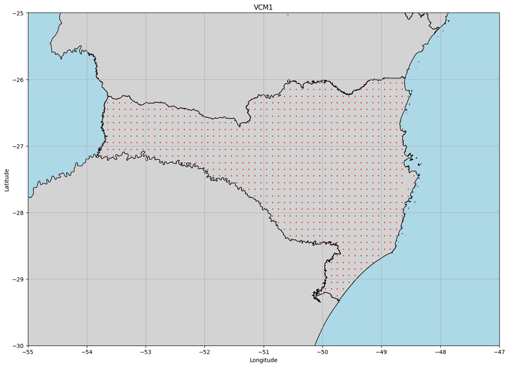

```python
# coordenadas_filtradas = Lon_-48,95 Lat_-27,75	Lon_-48,95 Lat_-27,65	Lon_-48,85 Lat_-27,85	Lon_-48,85 Lat_-27,75	Lon_-48,85 Lat_-27,65	Lon_-48,75 Lat_-27,75	Lon_-48,75 Lat_-27,65	Lon_-48,65 Lat_-27,55	Lon_-48,55 Lat_-27,75	Lon_-48,55 Lat_-27,65	Lon_-48,45 Lat_-27,55	Lon_-48,45 Lat_-27,45

# Gerando todas as combinações de latitudes e longitudes
combinacoes = coordenadas_filtradas

# Criando um DataFrame com as combinações de latitudes e longitudes
df_pontos = pd.DataFrame(combinacoes, columns=['lon', 'lat'])

# Criando o GeoDataFrame com os pontos
geometry = [Point(xy) for xy in zip(df_pontos['lat'], df_pontos['lon'])]
vcm1 = gpd.GeoDataFrame(df_pontos, geometry=geometry, crs="EPSG:4674")

# Plotando o mapa
fig, ax = plt.subplots(figsize = (15, 12))
coord_atlantico = [(-90, -40),(-30, -40),
	               (-30, 10),(-90, 10)]
atlantico_poly = Polygon(coord_atlantico)
atlantico = gpd.GeoDataFrame(geometry = [atlantico_poly])
atlantico.plot(ax = ax, color = "lightblue") # atlantico ~ base
ax.set_aspect("auto")

# Adicionando o shapefile do Brasil ao plot
br.plot(ax=ax, color='lightgrey', edgecolor='black')

# Plotando os pontos
vcm1.plot(ax=ax, color='red', markersize=1)


# Configurando o título e os rótulos dos eixos
plt.xlabel('Longitude')
plt.ylabel('Latitude')
plt.title('Pontos sobre o Mapa do Brasil')
plt.xlim(-55, -47)
plt.ylim(-30, -25)
plt.xlabel("Longitude")
plt.ylabel("Latitude")
plt.title(f"VCM1")
plt.grid(True)

#Salvando o mapa:
plt.savefig('../output_data/images/Pontos_Bacia_hidro_SC.png', dpi=900, bbox_inches='tight')

# Exibindo o gráfico
plt.show()
```

#### Bacia Rio Cubatão do Sul (pontos)

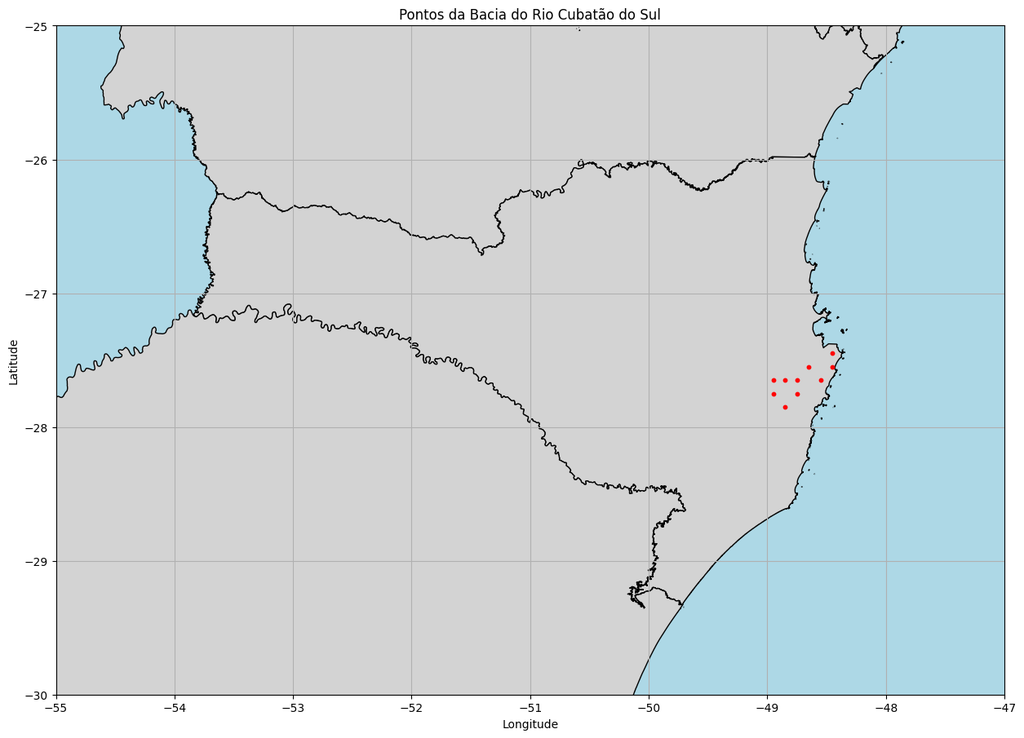

```python
# coordenadas_filtradas = [(-27.75, -48.95), (-27.65, -48.95), (-27.85, -48.85), (-27.75, -48.85), (-27.65, -48.85), (-27.75, -48.75), (-27.65, -48.75), (-27.55, -48.65),(-27.65, -48.55), (-27.55, -48.45), (-27.45, -48.45)]
coordenadas_filtradas = [(-27.75, -48.95), (-27.65, -48.95), (-27.85, -48.85),(-27.65, -48.85), (-27.75, -48.75), (-27.65, -48.75), (-27.55, -48.65),(-27.65, -48.55), (-27.55, -48.45), (-27.45, -48.45)]

# Gerando todas as combinações de latitudes e longitudes

combinacoes = coordenadas_filtradas

# Criando um DataFrame com as combinações de latitudes e longitudes
df_pontos = pd.DataFrame(combinacoes, columns=['lon', 'lat'])

# Criando o GeoDataFrame com os pontos
geometry = [Point(xy) for xy in zip(df_pontos['lat'], df_pontos['lon'])]
vcm1 = gpd.GeoDataFrame(df_pontos, geometry=geometry, crs="EPSG:4674")

# Plotando o mapa
fig, ax = plt.subplots(figsize = (15, 12))
coord_atlantico = [(-90, -40),(-30, -40),
	               (-30, 10),(-90, 10)]
atlantico_poly = Polygon(coord_atlantico)
atlantico = gpd.GeoDataFrame(geometry = [atlantico_poly])
atlantico.plot(ax = ax, color = "lightblue") # atlantico ~ base
ax.set_aspect("auto")

# Adicionando o shapefile do Brasil ao plot
br.plot(ax=ax, color='lightgrey', edgecolor='black')

# Plotando os pontos
vcm1.plot(ax=ax, color='red', markersize=10) # 5 é o tamanho dos dots das coordenadas


# Configurando o título e os rótulos dos eixos
#plt.xlabel('Longitude')
#plt.ylabel('Latitude')
#plt.title('Pontos da Bacia do Rio Cubatão do Sul')
plt.xlim(-55, -47)
plt.ylim(-30, -25)
plt.xlabel("Longitude")
plt.ylabel("Latitude")
plt.title(f"Pontos da Bacia do Rio Cubatão do Sul")
plt.grid(True)

# Salvando o gráfico
plt.savefig('../output_data/images/Pontos_Bacia_hidro_Rio_Cubatao_do_Sul.png', dpi=900, bbox_inches='tight')

# Exibindo o gráfico
plt.show()
```

```python
# Obtenha as colunas como uma lista
colunas = dfEmpilhado.columns.tolist()

# Crie um DataFrame com as colunas
df_colunas = pd.DataFrame({'Colunas': colunas})

# Salve as colunas em um arquivo CSV
df_colunas.to_csv('../output_data/database/colunas_dfEmpilhado.csv', index=False)

# Salvando o dafaframe num arquivo csv
dfEmpilhado.to_csv('../output_data/database/precipitacao_Empilhadoc.csv')
```